# Practical Tidyverse Examples

Angelica Pan

**Goal**: See practical examples of using tidyverse packages and user-defined functions to analyze and visualize a psycholinguistic experiment.

**Prerequisites**: You should be familiar with the tidyverse package **dplyr** and psycholinguistic experiment analysis.

# 1 Introduction

This document uses tidyverse packages to analyze and visualize data from a real psycholinguistic experiment, the eye tracking while reading experiment `RC`. This guide also introduces user-defined functions, and provides examples of defining functions to facilitate data analysis and visualization.

# 2 `RC`

`RC` is an eye tracking while reading experiment conducted at the [UCLA Language Processing Lab](http://processing.linguistics.ucla.edu/) by [Angelica Pan](https://angelica-pan.com/) and supervised by [Jesse Harris](https://jesseharris.netlify.app/). Data was collected by an [SR Eyelink 1000 Tower Mount](https://www.sr-research.com/eyelink-1000-plus/#TowerMount) and preprocessed with [EyeDry](https://blogs.umass.edu/eyelab/software/).

## 2.1 Eye tracking while reading

In an eye tracking while reading experiment, subjects read text that is displayed on a computer screen. As they read, a high speed camera records their eye movements. Eye tracking while reading is a popular method for studying sentence processing because certain eye movement patterns, such as long fixations on difficult sentence structures, have been linked to cognitive effort.

> To learn more about eye tracking, read [Eye Movements in Reading Words and Sentences (2007)](http://people.umass.edu/cec/CliftonStaubRaynerECEM.pdf) by Charles Clifton Jr., Adrian Staub, and Keith Rayner.

## 2.2 Experimental Design

`RC` has a 2x2 latin square design, crossing relative clause matrix position (`pos`) with relative clause extraction type (`ext`). This experiment looked at the effects of `pos` and `ext` on relative clause processing difficulty.

Factors and levels:

- `pos`: *matrix subject (SUB)* or **matrix object (OBJ)**
- `ext`: subject-extracted (SRC) or object-extracted (ORC)

## 2.3 Experimental items

Experimental items are sentence quartets:

- *SUB-SRC*: Unsurprisingly, the diplomat *who attacked the senator* earlier this afternoon avoided the reporter at the charity event.
- *SUB-ORC*: Unsurprisingly, the diplomat *who the senator attacked* earlier this afternoon avoided the reporter at the charity event.
- **OBJ-SRC**: Unsurprisingly, the diplomat avoided the reporter **who attacked the senator** earlier this afternoon at the charity event.
- **OBJ-ORC**: Unsurprisingly, the diplomat avoided the reporter **who the senator attacked** earlier this afternoon at the charity event.

## 2.4 Regioning

During the experiment, subjects read experimental items as a single line of unbroken text displayed on a computer monitor.

Items are split into 7 regions for analysis:

- **intro**: introductory region
- **msub**: matrix subject region
- **RC**: relative clause region (also called “region of interest”, or “critical region”")
- **spillover**: spillover region
- **mverb**: matrix verb region
- **mobj**: matrix object region
- **final**: final region

The linear order of the regions differs across the *SUB* and **OBJ** levels.

Region order for *SUB* items:

- intro<sup>1</sup> | msub<sup>2</sup> | RC<sup>3</sup> | spillover<sup>4</sup> | mverb<sup>5</sup> | mobj<sup>6</sup> | final<sup>7</sup>

Region order for **OBJ** items:

- intro<sup>1</sup> | msub<sup>2</sup> | mverb<sup>3</sup> | mobj<sup>4</sup> | RC<sup>5</sup> | spillover<sup>6</sup> | final<sup>7</sup>

## 2.5 Preprocessing

EyeDry is a program that preprocesses eye tracking data. It extracts eye movement metrics from raw eye tracking data into `<metric>.ixs` files, which are tabular data that can be read into a R data frame.

Eye tracking metrics mentioned in this guide:

- first pass times (**fp**):the sum of all fixations in a region until the first fixation to the region’s left or right
- right-bounded times (**rb**): the sum of all fixations in a region until the first fixation to the region’s right
- second pass times (**sp**): the sum of all fixations in a region after the initial first pass fixations

EyeDry also detects if and where a subject blinked while reading a sentence during an experimental trial. Trials with too many blinks on a specified critical region are excluded because no eye movement information can be recorded when a subject blinks.

The critical region in EyeDry is specified by linear order. However, in `RC` the critical **RC** region is the linearly 3rd region for *SUB* items, but the linarly 5th region for **OBJ** items.

- *SUB* items: Unsurprisingly, | the diplomat | *who attacked the senator*<sup>3</sup> | avoided | the reporter | …
- **OBJ** items: Unsurprisingly, | the diplomat | avoided | the reporter | **who attacked the senator**<sup>5</sup> | …

To solve this issue, the `RC` data was split into two files, one with data from the *SUB* item trials and one with data from the **OBJ** item trials. EyeDry was run separately on each file.

In the `RC` experiment, the data for each eye movement metric is therefore contained in two files:

- `<metric>-rcs.ixs`: eye movement metric data from *SUB* item trials
- `<metric>-rco.ixs`: eye movement metric data from **OBJ** item trials.

> During analysis, the corresponding `<metric>-rcs.ixs` and `<metric>-rco.ixs` files for each metric must be joined for a complete set of values.

## 2.6 First pass times

A first pass time is the sum of all fixations made in a given region from the first time the point of fixation enters the region until the the first time the point of fixation leaves the region. To learn more about first pass times, read [Eye Movements in Reading Words and Sentences](https://people.umass.edu/cec/CliftonStaubRaynerECEM.pdf).

First pass times are an “early” eye tracking metric, meaning that first pass fixations are associated with initial sentence processing processes.

> Most examples in this guide use first pass times data.

# 3 Data manipulation

This section uses **dplyr** functions to manipulate first pass time time data from the `RC` experiment. For a review on **dplyr**, read the Tidyverse Data Manipulation Quickstart.

## 3.1 `.ixs` files

The first pass (fp) time data is contained within `fp-rcs.ixs` and `fp-rco.ixs`. They are comma-delimited files in which the first row contains the column names.

> The full `.ixs` files that appear in this guide are currently not available to the public.

First 8 lines of `fp-rcs.ixs`:

```
seq,subj,item,cond,region,datum
26,1,1,5,1,318
26,1,1,5,2,311
26,1,1,5,3,488
26,1,1,5,4,350
26,1,1,5,5,171
26,1,1,5,6,356
26,1,1,5,7,696
```

First 8 lines of `fp-rco.ixs`:

```
seq,subj,item,cond,region,datum
133,1,3,7,1,323
133,1,3,7,2,417
133,1,3,7,3,
133,1,3,7,4,216
133,1,3,7,5,527
133,1,3,7,6,218
133,1,3,7,7,
```

The columns are:

- `seq`: sequence number
- `subj`: subject number (40 subjects)
- `item`: item number (16 experimental items)
- `cond`: condition number (4 conditions)
- `region`: region number (7 regions per experimental item)
- `datum`: length of fixation in ms

Each experimental item is split into 7 rows of data, one for each region.

## 3.2 Reading in data

Use `dplyr::read_delim()` to read in the `.ixs` files as a tibble:

```r
# Read in first pass times for SUB items
fp_rcs <- read_delim("./fp-rcs.ixs", delim = ",", col_names = TRUE)

# Read in first pass times for OBJ items
fp_rco <- read_delim("./fp-rco.ixs", delim = ",", col_names = TRUE)
```

Print the newly created data frames:

```r
# First pass times for SUB items
fp_rcs
```

```
# A tibble: 2,058 x 6
     seq  subj  item  cond region datum
   <dbl> <dbl> <dbl> <dbl>  <dbl> <dbl>
 1    26     1     1     5      1   318
 2    26     1     1     5      2   311
 3    26     1     1     5      3   488
 4    26     1     1     5      4   350
 5    26     1     1     5      5   171
 6    26     1     1     5      6   356
 7    26     1     1     5      7   696
 8    27     1     2     6      1   470
 9    27     1     2     6      2   133
10    27     1     2     6      3   405
# … with 2,048 more rows
```

```r
# First pass times for OBJ items
fp_rco
```

```
# A tibble: 2,093 x 6
     seq  subj  item  cond region datum
   <dbl> <dbl> <dbl> <dbl>  <dbl> <dbl>
 1   133     1     3     7      1   323
 2   133     1     3     7      2   417
 3   133     1     3     7      3    NA
 4   133     1     3     7      4   216
 5   133     1     3     7      5   527
 6   133     1     3     7      6   218
 7   133     1     3     7      7    NA
 8    47     1     7     7      1   300
 9    47     1     7     7      2   205
10    47     1     7     7      3   184
# … with 2,083 more rows
```

## 3.3 Creating columns

We will separately create 2 columns on the `fp_rcs` and `fp_rco` data frames before combining the data frames.

- `pos`: identify whether a row is from a *SUB* or **OBJ** item
- `ext`: identify whether a row is from a SRC or ORC item

### 3.3.1 `pos`

The `pos` column identifies whether a row is from a *SUB* or **OBJ** item.

Use `mutate()`:

```r
# All items in `fp-rcs.ixs` are SUB items
fp_rcs <- read_delim("./fp-rcs.ixs", delim = ",", col_names = TRUE) %>%
  mutate(pos = "SUB")

# All items in `fp-rco.ixs` are OBJ items
fp_rco <- read_delim("./fp-rcs.ixs", delim = ",", col_names = TRUE) %>%
  mutate(pos = "OBJ")
```

### 3.3.2 `ext`

The `ext` column identifies whether a row is from a SRC or ORC item.

The value of a row’s `ext` column can be created from the `cond` column, which identifies the experimental condition of that row/item:

- `cond == 5`: *SUB-SRC*
- `cond == 6`: *SUB-ORC*
- `cond == 7`: **OBJ-SRC**
- `cond == 8`: **OBJ-ORC**

`fp-rcs.ixs` only contains *SUB* items (rows with a `cond` value of `5` or `6`):

- If `cond == 5`, then `ext == SRC`
- Else, `cond == 6` and `ext == ORC`

`fp-rco.ixs` only contains **OBJ** items (rows with a `cond` value of `7` or `8`):

- If `cond == 7`, then `ext == SRC`
- Else, `cond == 8` and `ext == ORC`

Use `mutate()` and `dplyr::if_else()`:

```r
# If `cond` is `5`, then the item is an SRC, else an ORC.
fp_rcs <- read_delim("./fp-rcs.ixs", delim = ",", col_names = TRUE) %>%
  mutate(pos = "SUB",
         ext = if_else(cond == 5, "SRC", "ORC"))

# If `cond` is `7`, then the item is an SRC, else an ORC.
fp_rco <- read_delim("./fp-rco.ixs", delim = ",", col_names = TRUE) %>%
  mutate(pos = "OBJ",
         ext = if_else(cond == 7, "SRC", "ORC"))
```

## 3.4 Combining data frames

Combine the `fp_rcs` and `fp_rco` data frames into a single data frame with `dplyr::bind_rows()`:

```r
fp <- bind_rows(fp_rcs, fp_rco)

fp
```

```
# A tibble: 4,151 x 8
     seq  subj  item  cond region datum pos   ext
   <dbl> <dbl> <dbl> <dbl>  <dbl> <dbl> <chr> <chr>
 1    26     1     1     5      1   318 SUB   SRC
 2    26     1     1     5      2   311 SUB   SRC
 3    26     1     1     5      3   488 SUB   SRC
 4    26     1     1     5      4   350 SUB   SRC
 5    26     1     1     5      5   171 SUB   SRC
 6    26     1     1     5      6   356 SUB   SRC
 7    26     1     1     5      7   696 SUB   SRC
 8    27     1     2     6      1   470 SUB   ORC
 9    27     1     2     6      2   133 SUB   ORC
10    27     1     2     6      3   405 SUB   ORC
# … with 4,141 more rows
```

## 3.5 More manipulations

For manipulations that are independent of the *SUB* and **OBJ** items, it is more efficient to perform them on a combined `fp` data frame than to perform them twice on separate data frames:

- Factors: coercing character vectors into factors
- `cond2`: identify whether a row is from a *SUB-SRC*, *SUB-ORC*, **OBJ-SRC**, or **OBJ-ORC** item
- `region2`: identify whether a row is the **intro**, **msub**, **RC**, **spillover**, **mverb**, **mobj**, or **final** region of an item

### 3.5.1 Coercing factors

The newly created `pos` and `ext` columns are character class vectors:

```r
# Check the class of the `pos` column
class(fp$pos)
```

```
[1] "character"
```

```r
# Check the class of the `ext` column
class(fp$ext)
```

```
[1] "character"
```

However, in this experiment, they should actually be factors with two levels.

Use `mutate()` and `base::factor()` to coerce the `pos` and `ext` columns into factors:

```r
fp <- bind_rows(fp_rcs, fp_rco) %>%
  # Coerce `pos` and `ext` columns into factors with the specified levels
  mutate(pos = factor(pos, levels = c("SUB", "OBJ")),
         ext = factor(ext, levels = c("SRC", "ORC")))
```

```r
# Check the class of the `pos` column
class(fp$pos)
```

```
[1] "factor"
```

```r
# Check the class of the `ext` column
class(fp$ext)
```

```
[1] "factor"
```

### 3.5.2 `cond2`

The `cond2` column identifies whether a row is from a *SUB-SRC*, *SUB-ORC*, **OBJ-SRC**, or **OBJ-ORC** item.

Concatenate the `pos` and `ext` columns with `stringr::str_c()`, and coerce `cond2` into a factor for analysis:

```r
fp <- bind_rows(fp_rcs, fp_rco) %>%
  mutate(pos = factor(pos, levels = c("SUB", "OBJ")),
         ext = factor(ext, levels = c("SRC", "ORC")),
         # Create `cond2` column
         cond2 = str_c(pos, ext, sep = "-"),
         # Coerce `cond2` into a factor
         cond2 = factor(cond2, levels = c("SUB-SRC", "SUB-ORC", "OBJ-SRC", "OBJ-ORC")))
```

### 3.5.3 `region2`

The `region2` column identifies whether a row is the **intro**, **msub**, **RC**, **spillover**, **mverb**, **mobj**, or **final** region of an item.

The value of a row’s `region2` column can be determined by the value of the `region` and `pos` columns, following the region orders.

- If `region == 1`, then `region2 == "intro"`
- Else if `region == 2`, then `region2 == "msub"`
- Else if `region == 3` and `pos == "SUB"`, then `region2 == "RC"`
- Else if `region == 3` and `pos == "OBJ"`, then `region2 == "mverb"`
- etc.

`dplyr::case_when()` is the equivalent of nesting multiple `dplyr::if_else()` statements.

Use `mutate()` and `case_when()`:

```r
fp <- bind_rows(fp_rcs, fp_rco) %>%
  mutate(pos = factor(pos, levels = c("SUB", "OBJ")),
         ext = factor(ext, levels = c("SRC", "ORC")),
         cond2 = str_c(pos, ext, sep = "-"),
         cond2 = factor(cond2, levels = c("SUB-SRC", "SUB-ORC", "OBJ-SRC", "OBJ-ORC")),
         # Create `region2` column
         region2 = case_when(region == 1 ~ "intro",
                             region == 2 ~ "msub",
                             region == 3 & pos == "SUB" ~ "RC",
                             region == 3 & pos == "OBJ" ~ "mverb",
                             region == 4 & pos == "SUB" ~ "spillover",
                             region == 4 & pos == "OBJ" ~ "mobj",
                             region == 5 & pos == "SUB" ~ "mverb",
                             region == 5 & pos == "OBJ" ~ "RC",
                             region == 6 & pos == "SUB" ~ "mobj",
                             region == 6 & pos == "OBJ" ~ "spillover",
                             region == 7 ~ "final"))

fp
```

```
# A tibble: 4,151 x 10
     seq  subj  item  cond region datum pos   ext   cond2   region2
   <dbl> <dbl> <dbl> <dbl>  <dbl> <dbl> <fct> <fct> <fct>   <chr>
 1    26     1     1     5      1   318 SUB   SRC   SUB-SRC intro
 2    26     1     1     5      2   311 SUB   SRC   SUB-SRC msub
 3    26     1     1     5      3   488 SUB   SRC   SUB-SRC RC
 4    26     1     1     5      4   350 SUB   SRC   SUB-SRC spillover
 5    26     1     1     5      5   171 SUB   SRC   SUB-SRC mverb
 6    26     1     1     5      6   356 SUB   SRC   SUB-SRC mobj
 7    26     1     1     5      7   696 SUB   SRC   SUB-SRC final
 8    27     1     2     6      1   470 SUB   ORC   SUB-ORC intro
 9    27     1     2     6      2   133 SUB   ORC   SUB-ORC msub
10    27     1     2     6      3   405 SUB   ORC   SUB-ORC RC
# … with 4,141 more rows
```

# 4 Data analysis

This section provides examples of using **dplyr** functions to analyze first pass time data.

> The `.ixs` files contain missing values in the `datum` column, so summary functions should include an `na.rm = TRUE` argument.

## 4.1 Winsorizing

Winsorization is a method of reducing the effect of outliers by replacing extreme values with less extreme values.

Install and load the `psych` package for the the `psych::winsor()` function:

```r
install.packages("psych")
library(psych)
```

First pass times should be winsorized by experimental condition and region, because the different conditons and regions differ in length and difficulty.

Use `group_by()`, `mutate()`, and `winsor()` to winsorize by group:

```r
# Winsorize first pass times by condition and region
fp <- fp %>%
  group_by(cond2, region2) %>%
  mutate(win = winsor(datum, trim = 0.1, na.rm = TRUE)) %>%
  ungroup()

fp
```

```
# A tibble: 4,151 x 11
     seq  subj  item  cond region datum pos   ext   cond2   region2     win
   <dbl> <dbl> <dbl> <dbl>  <dbl> <dbl> <fct> <fct> <fct>   <chr>     <dbl>
 1    26     1     1     5      1   318 SUB   SRC   SUB-SRC intro      318
 2    26     1     1     5      2   311 SUB   SRC   SUB-SRC msub       311
 3    26     1     1     5      3   488 SUB   SRC   SUB-SRC RC         488
 4    26     1     1     5      4   350 SUB   SRC   SUB-SRC spillover  350
 5    26     1     1     5      5   171 SUB   SRC   SUB-SRC mverb      180.
 6    26     1     1     5      6   356 SUB   SRC   SUB-SRC mobj       356
 7    26     1     1     5      7   696 SUB   SRC   SUB-SRC final      696
 8    27     1     2     6      1   470 SUB   ORC   SUB-ORC intro      470
 9    27     1     2     6      2   133 SUB   ORC   SUB-ORC msub       189
10    27     1     2     6      3   405 SUB   ORC   SUB-ORC RC         405
# … with 4,141 more rows
```

## 4.2 Means and standard errors

The `RC` experiment looks at the effects of `pos` and `ext` on relative clause processing difficulty. Increased processing difficulty is associated with longer first pass time durations.

We should look at the average first pass time (with standard errors) for each condition and region group.

Install and load the `plotrix()` package for the the `plotrix::std.error()` function:

```r
install.packages("plotrix")
library(plotrix)
```

Use `group_by()`, `summarize()`, and `std.error()` to calculate mean first pass times with standard errors:

```r
# Calculate mean first pass times by condition and region
fp %>%
  group_by(region2, cond2) %>%
  summarize(avg = mean(win, na.rm = T), ste = std.error(win, na.rm = T))
```

```
# A tibble: 28 x 4
# Groups:   region2 [7]
   region2 cond2     avg   ste
   <chr>   <fct>   <dbl> <dbl>
 1 final   SUB-SRC  585. 26.7
 2 final   SUB-ORC  580. 23.2
 3 final   OBJ-SRC  545. 22.1
 4 final   OBJ-ORC  545. 22.2
 5 intro   SUB-SRC  523. 19.7
 6 intro   SUB-ORC  567. 20.5
 7 intro   OBJ-SRC  522. 21.0
 8 intro   OBJ-ORC  526. 19.7
 9 mobj    SUB-SRC  308.  8.86
10 mobj    SUB-ORC  312. 10.0
# … with 18 more rows
```

# 5 Data visualization

**ggplot2** is a tidyverse package for creating graphics. This section uses **ggplot2** to provide examples of tidyverse data visualization, but is not intended to be an introduction to **ggplot2**. To learn more about data visualization, read [Chapter 3 “Data visualization”](https://r4ds.had.co.nz/data-visualisation.html) of [*R for Data Science*](https://r4ds.had.co.nz/), by Garrett Grolemund and Hadley Wickham.

## 5.1 RC region

The `RC` experiment has a 2x2 factorial design. Line graphs are good for visualizing 2x2 factorials.

> To learn more about factorial design visualization, see [Chapter 10.2 “Interpreting main effects and interactions”](https://crumplab.github.io/statistics/more-on-factorial-designs.html#interpreting-main-effects-and-interactions) of [*Answering Questions with Data*](https://crumplab.github.io/statistics/) by Matthew Crump.

Create a line graph for the most important region, the critical **RC** region:

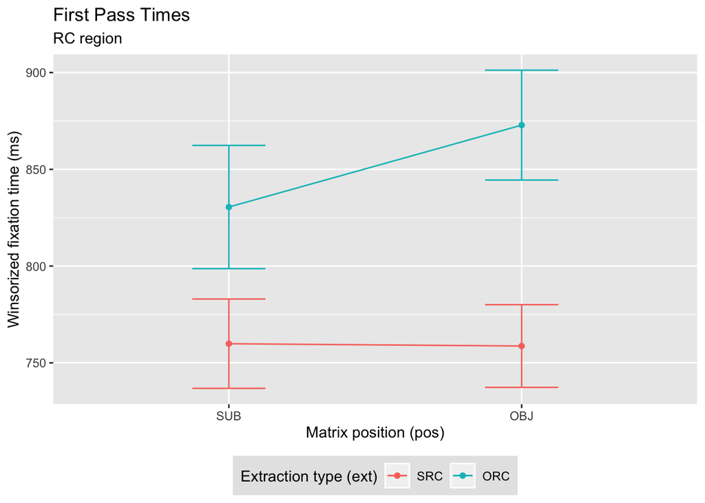

```r
# Pick out first pass data from the RC region only, and drop rows with missing values
fp_RC <- fp %>%
  filter(region2 == "RC") %>%
  drop_na()

# Create a line graph for `fp_RC` / the RC region
ggplot(fp_RC, aes(x = pos, y = win, group = ext, color = ext)) +
  labs(title = "First Pass Times", x = "Matrix position (pos)",
       y = "Winsorized fixation time (ms)", color = "Extraction type (ext)",
       subtitle = "RC region") +
  stat_summary(fun.y = mean, geom = "line") +
  stat_summary(fun.y = mean, geom = "point") +
  stat_summary(fun.data = mean_se, geom = "errorbar", width = 0.25) +
  theme(legend.position = "bottom", legend.box = "horizontal",
        legend.background = element_rect(fill = "grey90"),
        strip.background = element_rect(fill="grey90"))
```

## 5.2 All regions

In the `RC` experiment, the **RC** region is the most important. However, visualizing all regions can be helpful in interpreting main effects and interactions.

You can use `ggplot2::facet_wrap()` to create a facet, or subplot, for each region and display all facets in a single row.

There are two region orders, so there should be two facet orders:

- *SUB* items: intro<sup>1</sup> | msub<sup>2</sup> | RC<sup>3</sup> | spillover<sup>4</sup> | mverb<sup>5</sup> | mobj<sup>6</sup> | final<sup>7</sup>
- **OBJ** items: intro<sup>1</sup> | msub<sup>2</sup> | mverb<sup>3</sup> | mobj<sup>4</sup> | RC<sup>5</sup> | spillover<sup>6</sup> | final<sup>7</sup>

### 5.2.1 *SUB* item facet order

Create facets for all regions, following the *SUB* item region order:

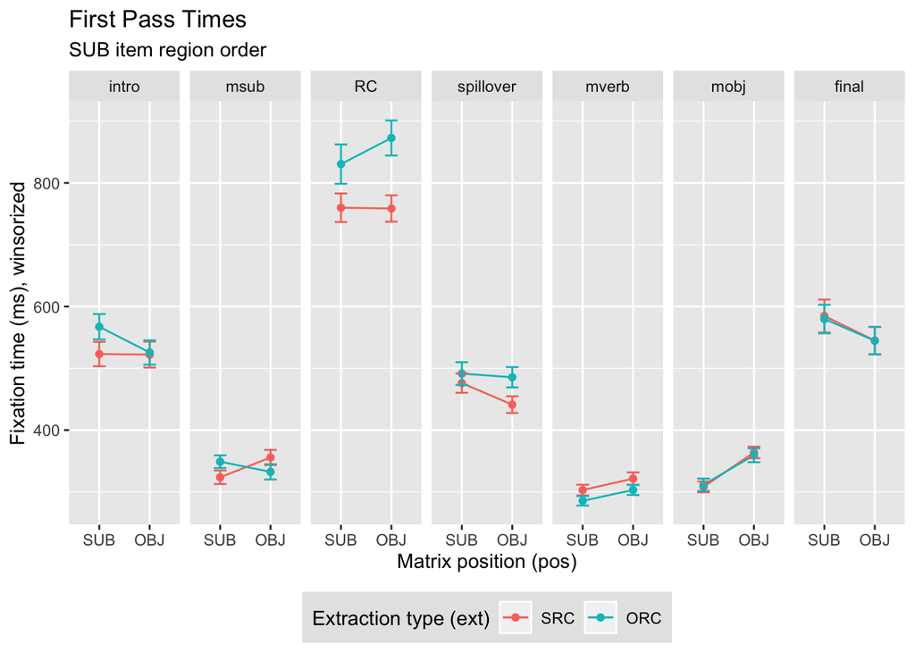

```r
# Create a copy of `fp` that coerces the `region2` column into a factor with levels.
# Specifying the levels sets the facet order.
fp_sub <-  fp %>%
    mutate(region2 = factor(region2, levels = c("intro", "msub", "RC", "spillover", "mverb", "mobj", "final"))) %>%
  drop_na()

# SUB item region order
ggplot(fp_sub, aes(x = pos, y = win, group = ext, color = ext)) +
  labs(title = "First Pass Times", x = "Matrix position (pos)",
       y = "Fixation time (ms), winsorized", color = "Extraction type (ext)",
       subtitle = "SUB item region order") +
  stat_summary(fun.y = mean, geom = "line") +
  stat_summary(fun.y = mean, geom = "point") +
  stat_summary(fun.data = mean_se, geom = "errorbar", width = 0.25) +
  theme(legend.position = "bottom", legend.box = "horizontal",
        legend.background = element_rect(fill = "grey90"),
        strip.background = element_rect(fill="grey90")) +
    # Create facet for each region and display all facets in a single row
    facet_wrap( ~ region2, nrow = 1)
```

### 5.2.2 **OBJ** item facet order

Create facets for all regions, following the **OBJ** item region order:

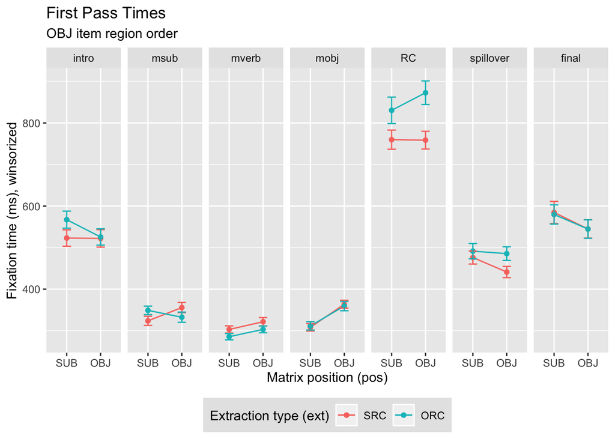

```r
# Create a copy of `fp` that coerces the `region2` column into a factor with levels.
# Specifying the levels sets the facet order.
fp_obj <-  fp %>%
    mutate(region2 = factor(region2, levels = c("intro", "msub", "mverb", "mobj", "RC", "spillover", "final"))) %>%
  drop_na()

# OBJ item region order
ggplot(fp_obj, aes(x = pos, y = win, group = ext, color = ext)) +
  labs(title = "First Pass Times", x = "Matrix position (pos)",
       y = "Fixation time (ms), winsorized", color = "Extraction type (ext)",
       subtitle = "OBJ item region order") +
  stat_summary(fun.y = mean, geom = "line") +
  stat_summary(fun.y = mean, geom = "point") +
  stat_summary(fun.data = mean_se, geom = "errorbar", width = 0.25) +
  theme(legend.position = "bottom", legend.box = "horizontal",
        legend.background = element_rect(fill = "grey90"),
        strip.background = element_rect(fill="grey90")) +
    # Create facet for each region and display all facets in a single row
    facet_wrap( ~ region2, nrow = 1)
```

# 6 User-defined functions

You can define a function in R with the following syntax:

```r
# Define `function_name()`
function_name <- function(argument1, argument2, ...){
  # some computation involving the arguments
}

# Call `function_name()`
function_name(argument1, argument2)
```

User-defined functions (UDFs) allow you to reuse code easily. Writing and calling a UDF is more powerful than simply copy-and-pasting code for several reasons, including :

- UDFs lower the chance of copy-and-paste errors, like forgetting to change a variable name in a copied code block.
- UDFs update easily; changing the code in a UDF once is easier than changing the code many times in copied code blocks.
- UDFs reduce overall code length and make R scripts easier to read.

> To learn more about user-defined functions, read [Chapter 19 “Functions”](https://r4ds.had.co.nz/functions.html) of [*R for Data Science*](https://r4ds.had.co.nz/), by Garrett Grolemund and Hadley Wickham.

## 6.1 UDFs and data manipulation

This section provides an example of defining a function to make data manipulation easier.

### 6.1.1 `combine_sub_obj()`

In Section 3 Data manipulation, we read in the `fp-rcs.ixs` and `fp-rco.ixs` files and performed various manipulations to create the first pass times `fp` data frame:

```r
#### First pass times
# Read in `fp-rcs.ixs`
fp_rcs <- read_delim("./fp-rcs.ixs", delim = ",", col_names = TRUE) %>%
  mutate(pos = "SUB",
         ext = if_else(cond == 5, "SRC", "ORC"))

# Read in `fp-rco.ixs`
fp_rco <- read_delim("./fp-rco.ixs", delim = ",", col_names = TRUE) %>%
  mutate(pos = "OBJ",
         ext = if_else(cond == 7, "SRC", "ORC"))

# Combine `fp_rcs` and `fp_rco` data frames
fp <- bind_rows(fp_rcs, fp_rco) %>%
  mutate(pos = factor(pos, levels = c("SUB", "OBJ")),
         ext = factor(ext, levels = c("SRC", "ORC")),
         cond2 = str_c(pos, ext, sep = "-"),
         cond2 = factor(cond2, levels = c("SUB-SRC", "SUB-ORC", "OBJ-SRC", "OBJ-ORC")),
         region2 = case_when(region == 1 ~ "intro",
                             region == 2 ~ "msub",
                             region == 3 & pos == "SUB" ~ "RC",
                             region == 3 & pos == "OBJ" ~ "mverb",
                             region == 4 & pos == "SUB" ~ "spillover",
                             region == 4 & pos == "OBJ" ~ "mobj",
                             region == 5 & pos == "SUB" ~ "mverb",
                             region == 5 & pos == "OBJ" ~ "RC",
                             region == 6 & pos == "SUB" ~ "mobj",
                             region == 6 & pos == "OBJ" ~ "spillover",
                             region == 7 ~ "final"))
```

First pass times are just one eye tracking metric. EyeDry calculates other eye tracking metrics, like right-bounded times and second pass times.

- right-bounded times (**rb**): the sum of all fixations in a region until the first fixation to the region’s right
- second pass times (**sp**): the sum of all fixations in a region after the initial first pass fixations

The data for each eye tracking metric is contained in a pair of `<metric>-rcs.ixs` and `<metrix>-rco.ixs` files that must be read in and transformed like the first pass times data:

- `rb-rcs.ixs`: right-bounded times data for *SUB* items
- `rb-rco.ixs`: right-bounded times data for **OBJ** items
- `sp-rcs.ixs`: second pass times data for *SUB* items
- `sp-rco.ixs`: second pass times data for **OBJ** items

It would be redundant and error-prone to copy-and-paste the **dplyr** manipulations for every eye tracking metric.

Instead, define a function like `combine_sub_obj()`:

```r
# `combine_sub_obj()`: Read in, combine, and manipulate the `.ixs` files
combine_sub_obj <- function(sub, obj){
  rcs <- read_delim(sub, delim = ",", col_names = TRUE) %>%
    mutate(pos = "SUB",
           ext = if_else(cond == 5, "SRC", "ORC"))

  rco <- read_delim(obj, delim = ",", col_names = TRUE) %>%
    mutate(pos = "OBJ",
           ext = if_else(cond == 7, "SRC", "ORC"))

  bind_rows(rcs, rco) %>%
  mutate(pos = factor(pos, levels = c("SUB", "OBJ")),
         ext = factor(ext, levels = c("SRC", "ORC")),
         cond2 = str_c(pos, ext, sep = "-"),
         cond2 = factor(cond2, levels = c("SUB-SRC", "SUB-ORC", "OBJ-SRC", "OBJ-ORC")),
         region2 = case_when(region == 1 ~ "intro",
                             region == 2 ~ "msub",
                             region == 3 & pos == "SUB" ~ "RC",
                             region == 3 & pos == "OBJ" ~ "mverb",
                             region == 4 & pos == "SUB" ~ "spillover",
                             region == 4 & pos == "OBJ" ~ "mobj",
                             region == 5 & pos == "SUB" ~ "mverb",
                             region == 5 & pos == "OBJ" ~ "RC",
                             region == 6 & pos == "SUB" ~ "mobj",
                             region == 6 & pos == "OBJ" ~ "spillover",
                             region == 7 ~ "final"))
}
```

Create right-bounded times data frame:

```r
# Right-bounded times
rb <- combine_sub_obj("./rb-rcs.ixs", "./rb-rco.ixs")

rb
```

```
# A tibble: 4,151 x 10
     seq  subj  item  cond region datum pos   ext   cond2   region2
   <dbl> <dbl> <dbl> <dbl>  <dbl> <dbl> <fct> <fct> <fct>   <chr>
 1    26     1     1     5      1   318 SUB   SRC   SUB-SRC intro
 2    26     1     1     5      2   311 SUB   SRC   SUB-SRC msub
 3    26     1     1     5      3   488 SUB   SRC   SUB-SRC RC
 4    26     1     1     5      4   350 SUB   SRC   SUB-SRC spillover
 5    26     1     1     5      5   171 SUB   SRC   SUB-SRC mverb
 6    26     1     1     5      6   356 SUB   SRC   SUB-SRC mobj
 7    26     1     1     5      7  1271 SUB   SRC   SUB-SRC final
 8    27     1     2     6      1   470 SUB   ORC   SUB-ORC intro
 9    27     1     2     6      2   133 SUB   ORC   SUB-ORC msub
10    27     1     2     6      3   405 SUB   ORC   SUB-ORC RC
# … with 4,141 more rows
```

Create second pass times data frame:

```r
# Second pass times
sp <- combine_sub_obj("./sp-rcs.ixs", "./sp-rco.ixs")

sp
```

```
# A tibble: 4,151 x 10
     seq  subj  item  cond region datum pos   ext   cond2   region2
   <dbl> <dbl> <dbl> <dbl>  <dbl> <dbl> <fct> <fct> <fct>   <chr>
 1    26     1     1     5      1     0 SUB   SRC   SUB-SRC intro
 2    26     1     1     5      2     0 SUB   SRC   SUB-SRC msub
 3    26     1     1     5      3   456 SUB   SRC   SUB-SRC RC
 4    26     1     1     5      4   436 SUB   SRC   SUB-SRC spillover
 5    26     1     1     5      5   466 SUB   SRC   SUB-SRC mverb
 6    26     1     1     5      6   373 SUB   SRC   SUB-SRC mobj
 7    26     1     1     5      7     0 SUB   SRC   SUB-SRC final
 8    27     1     2     6      1     0 SUB   ORC   SUB-ORC intro
 9    27     1     2     6      2   249 SUB   ORC   SUB-ORC msub
10    27     1     2     6      3   944 SUB   ORC   SUB-ORC RC
# … with 4,141 more rows
```

## 6.2 UDFs and data analysis

This section provides examples of defining a function to make data analysis easier.

### 6.2.1 `win_datum()`

Section 4.1 Winsorizing described winsorizing first pass data:

```r
fp <- fp %>%
  group_by(cond2, region2) %>%
  mutate(win = winsor(datum, trim = 0.1, na.rm = TRUE)) %>%
  ungroup()
```

Define a function like `win_datum()` to automate this process:

```r
# `win_datum()`: Winsorize the `datum` column by condition and region
win_datum <- function(df){df %>%
    group_by(cond2, region2) %>%
    mutate(win = winsor(datum, trim = 0.1, na.rm = TRUE)) %>%
    ungroup()
}
```

Winsorize right-bounded times:

```r
# Winsorize right-bounded times by condition and region
rb <- rb %>%
  win_datum()

rb
```

```
# A tibble: 4,151 x 11
     seq  subj  item  cond region datum pos   ext   cond2   region2     win
   <dbl> <dbl> <dbl> <dbl>  <dbl> <dbl> <fct> <fct> <fct>   <chr>     <dbl>
 1    26     1     1     5      1   318 SUB   SRC   SUB-SRC intro      318
 2    26     1     1     5      2   311 SUB   SRC   SUB-SRC msub       311
 3    26     1     1     5      3   488 SUB   SRC   SUB-SRC RC         488
 4    26     1     1     5      4   350 SUB   SRC   SUB-SRC spillover  350
 5    26     1     1     5      5   171 SUB   SRC   SUB-SRC mverb      187.
 6    26     1     1     5      6   356 SUB   SRC   SUB-SRC mobj       356
 7    26     1     1     5      7  1271 SUB   SRC   SUB-SRC final     1271
 8    27     1     2     6      1   470 SUB   ORC   SUB-ORC intro      470
 9    27     1     2     6      2   133 SUB   ORC   SUB-ORC msub       189
10    27     1     2     6      3   405 SUB   ORC   SUB-ORC RC         606.
# … with 4,141 more rows
```

Ssecond pass times are generally not winsorized, so do not call `win_datum()` on the `sp` data frame.

### 6.2.2 `mean_summary()`

Section 4.2 Means and standard errors described calculating mean first pass times:

```r
fp %>%
  group_by(region2, cond2) %>%
  summarize(avg = mean(win, na.rm = T), ste = std.error(win, na.rm = T))
```

```
# A tibble: 28 x 4
# Groups:   region2 [7]
   region2 cond2     avg   ste
   <chr>   <fct>   <dbl> <dbl>
 1 final   SUB-SRC  585. 26.7
 2 final   SUB-ORC  580. 23.2
 3 final   OBJ-SRC  545. 22.1
 4 final   OBJ-ORC  545. 22.2
 5 intro   SUB-SRC  523. 19.7
 6 intro   SUB-ORC  567. 20.5
 7 intro   OBJ-SRC  522. 21.0
 8 intro   OBJ-ORC  526. 19.7
 9 mobj    SUB-SRC  308.  8.86
10 mobj    SUB-ORC  312. 10.0
# … with 18 more rows
```

Define a function like `mean_summary()` to automate this process:

```r
# `mean_summary()`: Calculate the average `column` value by condition and region
mean_summary <- function(df, column){
  column <- enquo(column)

  df %>%
    group_by(cond2, region2) %>%
    summarize(avg = mean(!!column, na.rm = T), ste = std.error(!!column, na.rm = T)) %>%
    ungroup()
}
```

`mean_summary()` takes 2 arguments:

- `df`: the data frame
- `column`: the value to calculate the mean of(`datum` for unwinsorized data, `win` for winsorized data)

Calculate the mean right-bounded times:

```r
# Average right-bounded times (winsorized)
rb %>%
  mean_summary(win)
```

```
# A tibble: 28 x 4
   cond2   region2     avg   ste
   <fct>   <chr>     <dbl> <dbl>
 1 SUB-SRC final      838.  32.8
 2 SUB-SRC intro      531.  19.8
 3 SUB-SRC mobj       343.  11.2
 4 SUB-SRC msub       340.  11.5
 5 SUB-SRC mverb      341.  11.6
 6 SUB-SRC RC         833.  21.6
 7 SUB-SRC spillover  528.  17.9
 8 SUB-ORC final      810   32.2
 9 SUB-ORC intro      570.  20.4
10 SUB-ORC mobj       375.  14.8
# … with 18 more rows
```

Calculate the mean second pass times:

```r
# Average second past times (not winsorized)
sp %>%
  mean_summary(datum)
```

```
# A tibble: 28 x 4
   cond2   region2     avg   ste
   <fct>   <chr>     <dbl> <dbl>
 1 SUB-SRC final      31.3  15.2
 2 SUB-SRC intro     201.   29.3
 3 SUB-SRC mobj      233.   26.1
 4 SUB-SRC msub      280.   28.0
 5 SUB-SRC mverb     326.   38.4
 6 SUB-SRC RC        769.   78.1
 7 SUB-SRC spillover 454.   50.8
 8 SUB-ORC final      33.0  13.6
 9 SUB-ORC intro     238.   36.6
10 SUB-ORC mobj      286.   35.1
# … with 18 more rows
```

## 6.3 UDFs and data visualization

This section provides examples of defining a function to make data visualization easier.

### 6.3.1 `linegraph_sub()`

Section 5.2.1 *SUB* item facet order described graphing first pass times, by *SUB* item region order:

```r
ggplot(fp_sub, aes(x = pos, y = win, group = ext, color = ext)) +
  labs(title = "First Pass Times", x = "Matrix position (pos)",
       y = "Fixation time (ms), winsorized", color = "Extraction type (ext)",
       subtitle = "SUB item region order") +
  stat_summary(fun.y = mean, geom = "line") +
  stat_summary(fun.y = mean, geom = "point") +
  stat_summary(fun.data = mean_se, geom = "errorbar", width = 0.25) +
  theme(legend.position = "bottom", legend.box = "horizontal",
        legend.background = element_rect(fill = "grey90"),
        strip.background = element_rect(fill="grey90")) +
    facet_wrap( ~ region2, nrow = 1)
```

Define a function like `linegraph_sub()` to automate this process:

```r
# `linegraph_sub()`: Create facets for all regions, following the SUB item order
linegraph_sub <- function(df, y.value, y.label, add.title){
  y.value <- enquo(y.value)

  df <- df %>%
    mutate(region2 = factor(region2, levels = c("intro", "msub", "RC", "spillover", "mverb", "mobj", "final"))) %>%
    drop_na()

  ggplot(df, aes(x = pos, y = !!y.value, group = ext, color = ext)) +
    labs(title = add.title, x = "Matrix position (pos)",
         y = y.label, color = "Extraction type (ext)",
         subtitle = "SUB Condition Order") +
    stat_summary(fun.y = mean, geom = "line") +
    stat_summary(fun.y = mean, geom = "point") +
    stat_summary(fun.data = mean_se, geom = "errorbar", width = 0.25) +
    theme(legend.position = "bottom", legend.box = "horizontal",
          legend.background = element_rect(fill = "grey90"),
          strip.background = element_rect(fill="grey90")) +
    facet_wrap( ~ region2, nrow = 1)
}
```

`linegraph_sub()` takes 4 arguments:

- `df`: the data frame
- `y.value`: the y-value of the graph (`datum` for unwinsorized data, `win` for winsorized data)
- `y.label`: the label for the y-value
- `add.title`: the title of the graph

Graph right-bounded times:

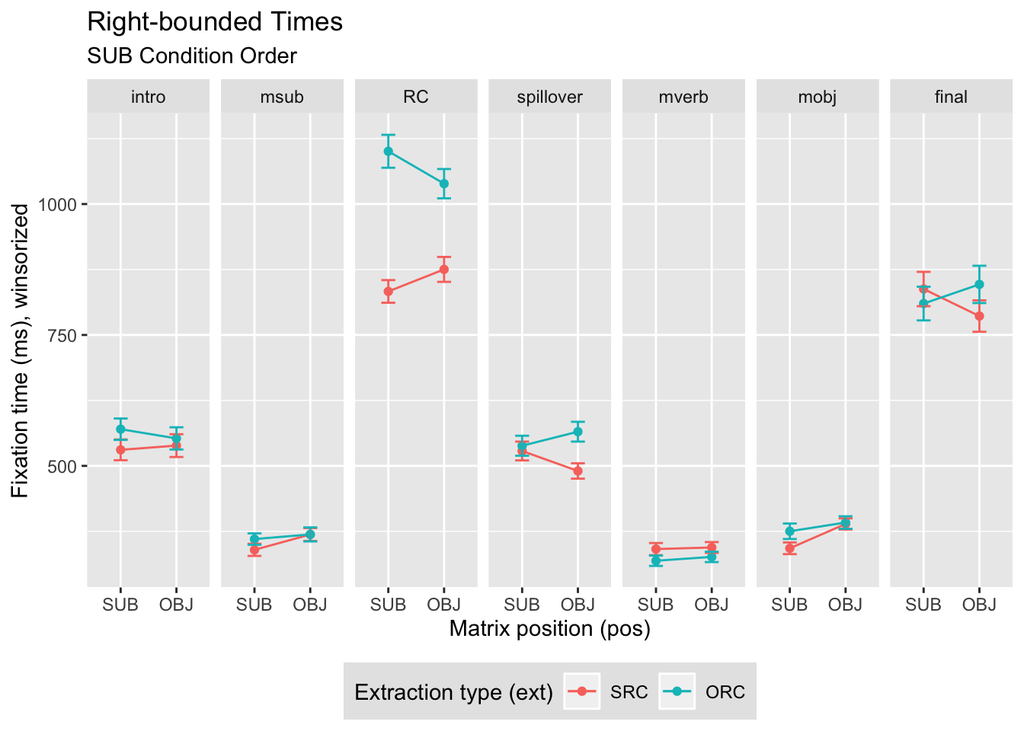

```r
# Graph of right-bounded times for all regions, SUB item order
linegraph_sub(rb, win, "Fixation time (ms), winsorized", "Right-bounded Times")
```

Graph second pass times:

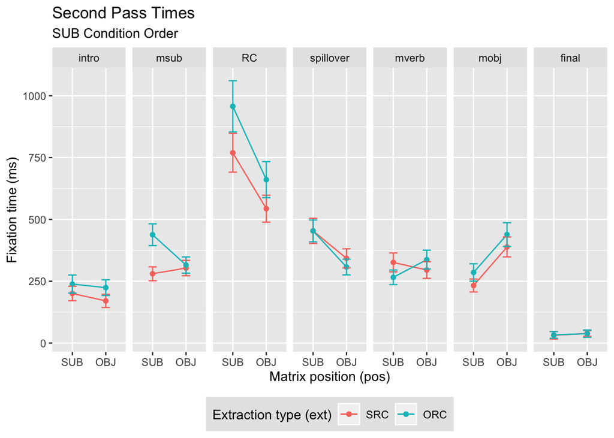

```r
# Graph of second pass times for all regions, SUB item order
linegraph_sub(sp, datum, "Fixation time (ms)", "Second Pass Times")
```

### 6.3.2 `linegraph_obj()`

Section 5.2.2 **OBJ** item facet order described graphing first pass times, by **OBJ** item region order:

```r
ggplot(fp_obj, aes(x = pos, y = win, group = ext, color = ext)) +
  labs(title = "First Pass Times", x = "Matrix position (pos)",
       y = "Fixation time (ms), winsorized", color = "Extraction type (ext)",
       subtitle = "OBJ item region order") +
  stat_summary(fun.y = mean, geom = "line") +
  stat_summary(fun.y = mean, geom = "point") +
  stat_summary(fun.data = mean_se, geom = "errorbar", width = 0.25) +
  theme(legend.position = "bottom", legend.box = "horizontal",
        legend.background = element_rect(fill = "grey90"),
        strip.background = element_rect(fill="grey90")) +
    facet_wrap( ~ region2, nrow = 1)
```

Define a function like `linegraph_obj()` to automate this process:

```r
# `linegraph_obj()`: Create facets for all regions, following the OBJ item order
linegraph_obj <- function(df, y.value, y.label, add.title){
  y.value <- enquo(y.value)

  df <- df %>%
    mutate(region2 = factor(region2, levels = c("intro", "msub", "mverb", "mobj", "RC", "spillover", "final"))) %>%
    drop_na()

  ggplot(df, aes(x = pos, y = !!y.value, group = ext, color = ext)) +
    labs(title = add.title, x = "Matrix position (pos)",
         y = y.label, color = "Extraction type (ext)",
         subtitle = "OBJ Condition Order") +
    stat_summary(fun.y = mean, geom = "line") +
    stat_summary(fun.y = mean, geom = "point") +
    stat_summary(fun.data = mean_se, geom = "errorbar", width = 0.25) +
    theme(legend.position = "bottom", legend.box = "horizontal",
          legend.background = element_rect(fill = "grey90"),
          strip.background = element_rect(fill="grey90")) +
    facet_wrap( ~ region2, nrow = 1)
}
```

`linegraph_obj()` takes 4 arguments:

- `df`: the data frame
- `y.value`: the y-value of the graph (`datum` for unwinsorized data, `win` for winsorized data)
- `y.label`: the label for the y-value
- `add.title`: the title of the graph

Graph right-bounded times:

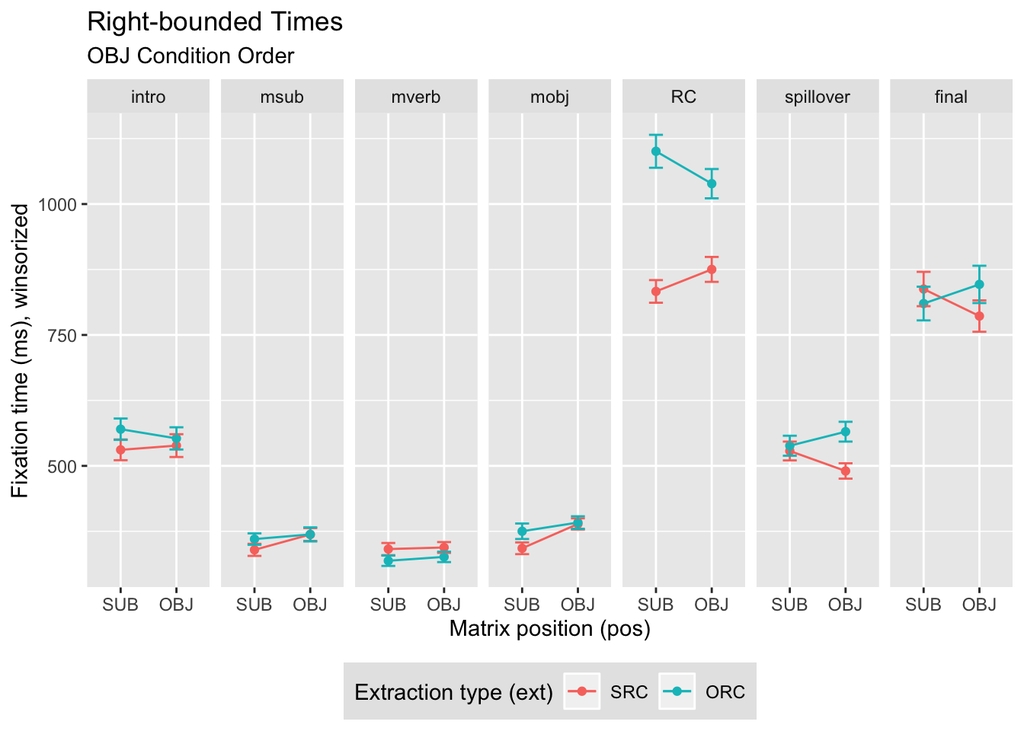

```r
# Graph of right-bounded times for all regions, OBJ item order
linegraph_obj(rb, win, "Fixation time (ms), winsorized", "Right-bounded Times")
```

Graph second pass times:

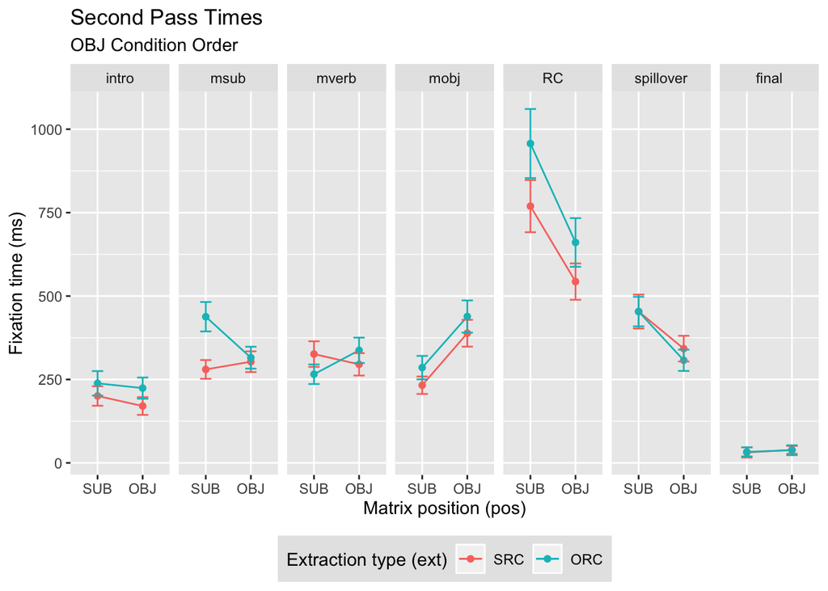

```r
# Graph of second pass times for all regions, OBJ item order
linegraph_obj(sp, datum, "Fixation time (ms)", "Second Pass Times")
```